# Wildfires in the US—Is it getting worse?!

Code Name: AF07

## Authors:

- Cynthia Chang (cchang17@uw.edu)
- Luis Chan (ylc22@uw.edu)
- Huiying Shen (hs243@uw.edu)
- Charlotte Lin (siyul6@uw.edu)

**Affiliation:** INFO-201: Technical Foundations of Informatics - The Information School - University of Washington

**Date:** Autumn 2022

## Abstract

This project aims to explore the causes of wildfires in the United States as well as the reasons of increased frequency. We find this topic important because the prevalence of wildfires has increased in the past few years in the Pacific Northwest and along the West Coast, as well as the Southern parts of the United States, and this increase affects the quality of life among those living in said areas, and could be detrimental to people who live with respiratory problems, like asthma.

## Keywords

wildfires, quality of life, aqi, climate change

## Introduction

Throughout the last decade, the problem of wildfires have been unprecedentedly increasing, to levels that we have never experienced before. While there are a number of underlying factors to why this issue has been prevalent across the United States, such as increasing temperatures, decreasing precipitation and human-made factors such as deforestation and urbanization, among all, the issue of global warming seems to be the major culprit behind this natural disaster. With increasing temperatures across the United States, the ecosystem is affected in different arrays such as a loss a vegetation and a decrease in water moisture in the soil. Dry weather due to global warming is also indispensably affiliated with the issue of wildfires.

Thus, with the mindset of data scientists, our group aims to use the three datasets below, from wildfire data to datasets of the land burned and temperature changes. we aim to delve into the underlying causes and trends of wildfires, and ultimately, how to we alleviate the issue and increase the quality of life of different stakeholders.

## The Problem Domain

The rate of wildfires has increased rapidly these past few years, directly affecting the air quality which also harms quality of life for many Americans. This may be due to many underlying factors, like global warming, or the increase of manmade fires. On October 19th, 2022, Seattle had the worst air quality in the world, and some West Coast cities like Portland, OR and Vancouver, BC were also ranked as some of the worst cities regarding air quality that week. With this unprecedented situation, this is an issue that we find important to explore. By knowing the history of it and its trends, we would like to raise awareness of this issue, and with more skills and knowledge, we could predict future trends by analyzing the data.

## Datasets

The first dataset we used was found on Kaggle, called *U.S. Wildfire data (plus other attributes)*, and it is subset from another dataset (called 1.88 Million Wildfires). This dataset combines 50,000 random fire samples and historical weather data at where the fire takes place, among other details. This dataset is important because it details fires from 1992-2015, which is a large span of time that can show trends of fire activity.

> [*https://www.kaggle.com/datasets/capcloudcoder/us-wildfire-data-plus-other-attributes*](https://www.kaggle.com/datasets/capcloudcoder/us-wildfire-data-plus-other-attributes)

The second dataset we found was from USAFacts, called Acres Burned in Wildfires. This data is important because it details how much land has been burned from the years 1983 to 2021, and it also reports how much land was burned by fires that were started by humans, or natural disasters, etc.

> [*https://usafacts.org/data/topics/security-safety/fire-and-disaster/fires-and-firefighters/forest-fire-acres/*](https://usafacts.org/data/topics/security-safety/fire-and-disaster/fires-and-firefighters/forest-fire-acres/)

The third dataset is also from Kaggle, and it consists of daily temperature data from major cities around the world, from 1995-2020. Prior to using this dataset, we shaved down the dataset to just cities in the United States. This dataset is important in regards to our research questions because we suspect that issue of global warming has a positive correlation to the increased frequency of wildfires, and by using this dataset, we hope to detect trends between increased average daily temperature and increased frequency of wildfires.

> [*https://www.kaggle.com/datasets/sudalairajkumar/daily-temperature-of-major-cities*](https://www.kaggle.com/datasets/sudalairajkumar/daily-temperature-of-major-cities)

## Research Questions:

1. Why has wildfires become a more prevalent problem now when it wasn’t in the past?
2. When in the year are fires more prevalent and what are the most common causes of fire (natural vs manmade)?
3. Is the prevalence of fires correlated with global warming, specifically the increase in the rise of average temperatures?

## Dynamic Paragraph

One of our research questions asked about the most common causes of wildfire (and whether it is due to natural causes, like lightning, or manmade, like campfires gone rogue), and after analyzing the data, we have discovered that the number one cause for wildfires discovered between 1992-2015 is **Debris Burning**. We were also curious about when in the year fires were most prevalent, and while most of us expected that it would be sometime during summer, wildfires are surprisingly most commonly discovered in **Mar**, or March. The state that has had the most number of fires in this time frame is **TX**, more commonly known as Texas. We also wanted to know if the increased frequency of fires is correlated with global warming, and through another dataset, we were able to calculate the average temperatures for every state. Surprisingly, the state with the highest temperature belongs to **Hawaii**, while Texas, the state that we originally expected to have the highest average temperature averaged at around **66.2116366**.

## Table for Aggregated data

| test | max_state | max_stat_cause_descr | max_discovery_month |
| --- | --- | --- | --- |
| 1992 | MS | Debris Burning | Mar |
| 1993 | GA | Debris Burning | Apr |
| 1994 | GA | Debris Burning | Mar |
| 1995 | MS | Debris Burning | Mar |
| 1996 | GA | Debris Burning | Feb |
| 1997 | GA | Arson | Apr |
| 1998 | GA | Arson | Aug |
| 1999 | GA | Debris Burning | Aug |
| 2000 | GA | Debris Burning | Aug |
| 2001 | GA | Debris Burning | Apr |
| 2002 | GA | Debris Burning | Feb |
| 2003 | CA | Debris Burning | Apr |
| 2004 | GA | Debris Burning | Mar |
| 2005 | TX | Debris Burning | Apr |
| 2006 | TX | Debris Burning | Mar |
| 2007 | GA | Debris Burning | Mar |
| 2008 | TX | Miscellaneous | Mar |
| 2009 | TX | Debris Burning | Mar |
| 2010 | TX | Debris Burning | Apr |
| 2011 | TX | Debris Burning | Aug |
| 2012 | TX | Debris Burning | Jul |
| 2013 | TX | Debris Burning | Mar |
| 2014 | TX | Debris Burning | Apr |
| 2015 | TX | Debris Burning | Jun |

## Chart 1: Top 10 Causes of Wildfire (1992-2015): Bar Chart

[output not shown]

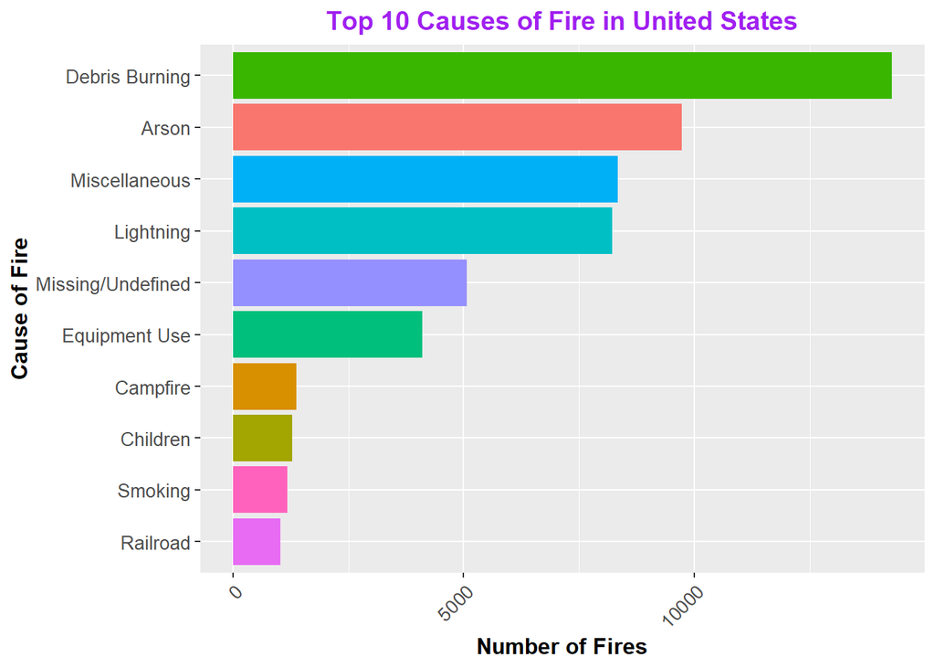

We used a bar chart to display and sort the top 10 fire causes in the United States. From the data we can see that Debris Burning is the most common cause of fires. Debris Burning refers to any spread of fire initially ignited to clear land or burn trash, garbage, crop residue or grass (excluding burning fires). Therefore, debris burning requires further control, and safety measures. This chart allows people to more clearly understand the causes of fires, and to carry out targeted management and prevention.

## Chart 2: Density Map of fires in the Mainland United States

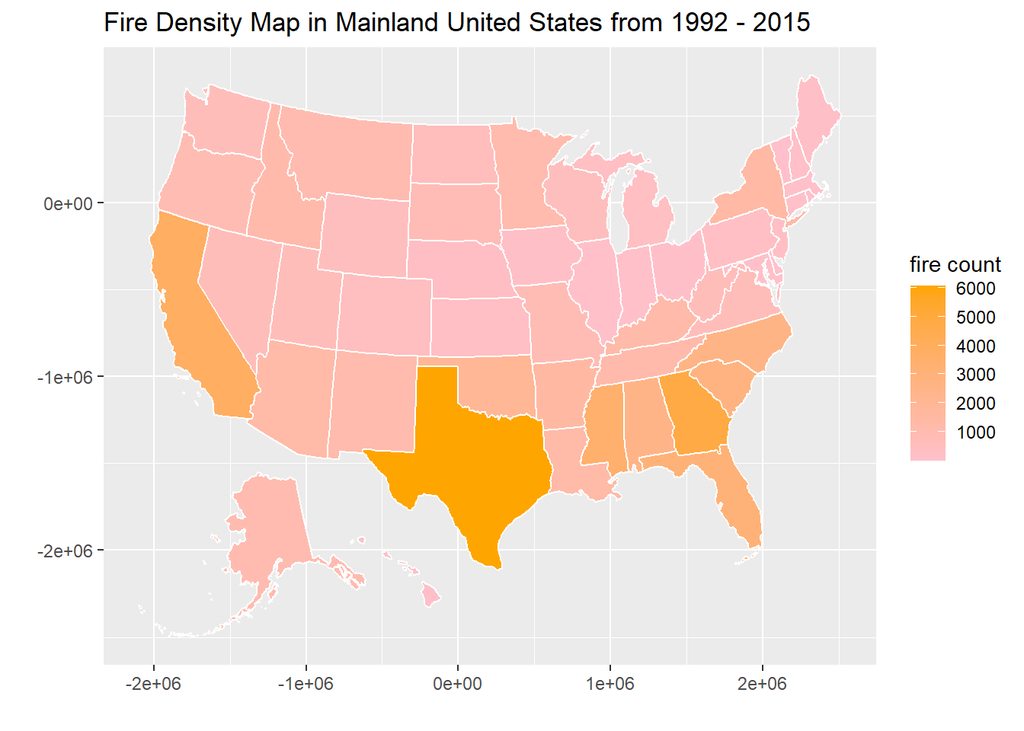

This density map of the United States depicts the number of fires that have happened in each state (in a random sample of 50,000 data observations) from 1992 to 2015. As we can see, Texas has suffered through the most wildfires in these past years, many of the Southern states and California are also more prone to wildfires than their northern companions. It could be because the Southern states typically have higher average temperatures, which make it easier for wildfires to start. This chart is important because it gives an insight on which states are more prone to wildfires, and also makes it all the more concerning when states like Washington suffer through intense wildfires: it makes us realize that global warming may be becoming more of a concern.

## Chart 3: Scatterplot Matrix of the Average Yearly Temperature in the United States, grouped by region

[output not shown]

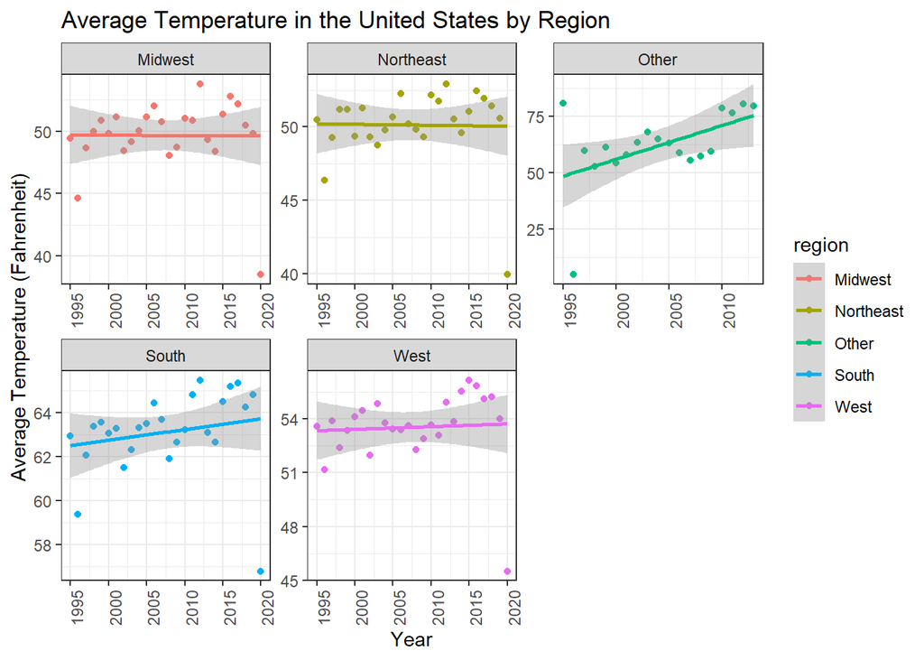

## References

[1] California wildfires wiped out nearly 20 years of greenhouse gas emission reductions in 2020, alone https://www.usatoday.com/story/news/nation/2022/10/18/california-wildfires-2020-greenhouse-gas-emissions/10524398002/

[2] Why are wildfires getting worse? These scientists explain https://www.weforum.org/agenda/2021/08/wildfires-united-states-cause-science

[3] Are wildfires increasing or decreasing? https://www.iqair.com/us/newsroom/wildfires-increasing-or-decreasing